# Olympiacos 84-78 Olimpia Milano

## Why the result went the way it did

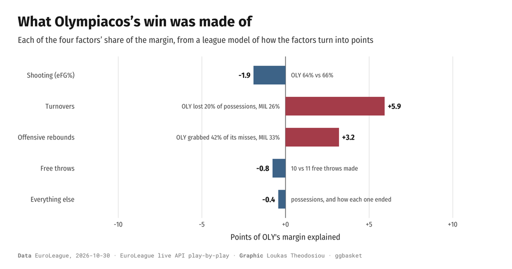

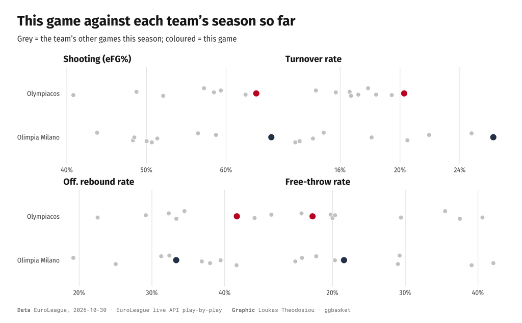

## Who mattered

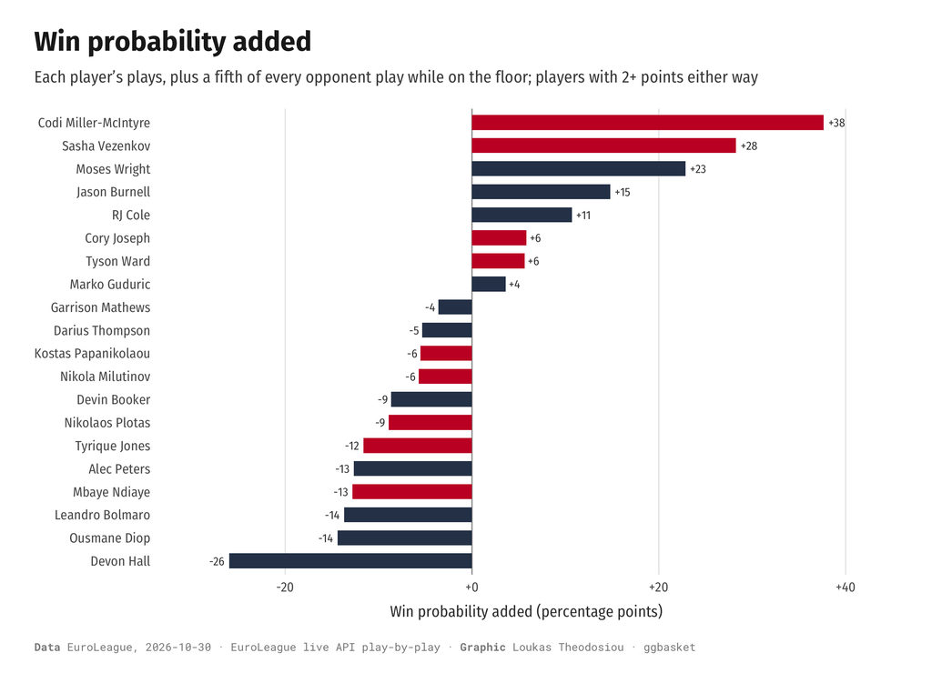

## Where the shots came from

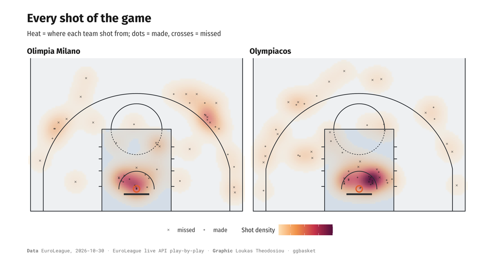

## Box scores

**Olympiacos**

| Player | MIN | PTS | 2P | 3P | FT | REB | AST | STL | BLK | TOV | +/- | GmSc |
| --- | --- | --- | --- | --- | --- | --- | --- | --- | --- | --- | --- | --- |
| Tyson Ward | 34 | 14 | 4/5 | 1/2 | 3/4 | 3 | 3 | 1 | 0 | 3 | 7 | 10.5 |
| Codi Miller-McIntyre | 32 | 24 | 5/10 | 4/9 | 2/3 | 3 | 4 | 0 | 0 | 3 | 18 | 13.8 |
| Sasha Vezenkov | 32 | 23 | 8/10 | 1/4 | 4/6 | 4 | 1 | 0 | 0 | 2 | 9 | 15.5 |
| Kostas Papanikolaou | 23 | 8 | 1/2 | 2/3 | 0/0 | 3 | 1 | 3 | 0 | 1 | 7 | 9.3 |
| Mbaye Ndiaye | 20 | 3 | 1/1 | 0/1 | 1/3 | 3 | 2 | 1 | 1 | 2 | -8 | 3.2 |
| Cory Joseph | 17 | 4 | 2/2 | 0/2 | 0/0 | 2 | 1 | 1 | 0 | 1 | -1 | 2.1 |
| Donta Hall | 13 | 4 | 2/4 | 0/0 | 0/0 | 3 | 2 | 0 | 0 | 0 | 6 | 4.3 |
| Tyrique Jones | 12 | 2 | 1/1 | 0/0 | 0/0 | 1 | 0 | 0 | 0 | 0 | 2 | 1.2 |
| Nikolaos Plotas | 12 | 2 | 1/1 | 0/0 | 0/0 | 1 | 0 | 0 | 0 | 0 | -10 | 1.6 |
| Nikola Milutinov | 5 | 0 | 0/1 | 0/0 | 0/0 | 1 | 0 | 0 | 0 | 1 | 0 | -1.0 |

**Olimpia Milano**

| Player | MIN | PTS | 2P | 3P | FT | REB | AST | STL | BLK | TOV | +/- | GmSc |
| --- | --- | --- | --- | --- | --- | --- | --- | --- | --- | --- | --- | --- |
| RJ Cole | 28 | 17 | 1/3 | 4/6 | 3/3 | 2 | 3 | 2 | 0 | 1 | -10 | 16.4 |
| Marko Guduric | 24 | 14 | 5/5 | 1/5 | 1/1 | 1 | 1 | 1 | 0 | 1 | -7 | 10.0 |
| Jason Burnell | 24 | 13 | 1/1 | 3/5 | 2/2 | 6 | 2 | 1 | 0 | 3 | -5 | 11.6 |
| Leandro Bolmaro | 22 | 3 | 0/1 | 1/2 | 0/0 | 0 | 4 | 0 | 0 | 0 | 10 | 2.1 |
| Devon Hall | 22 | 5 | 1/1 | 0/3 | 3/5 | 2 | 4 | 2 | 0 | 3 | -11 | 3.8 |
| Moses Wright | 22 | 16 | 7/10 | 0/1 | 2/2 | 5 | 2 | 1 | 1 | 6 | -1 | 8.9 |
| Alec Peters | 17 | 4 | 2/3 | 0/0 | 0/0 | 3 | 0 | 0 | 0 | 1 | -2 | 1.0 |
| Darius Thompson | 13 | 3 | 0/1 | 1/2 | 0/0 | 1 | 1 | 0 | 0 | 1 | 3 | 0.9 |
| Ousmane Diop | 11 | 0 | 0/0 | 0/0 | 0/2 | 0 | 0 | 1 | 0 | 0 | -5 | -0.2 |
| Garrison Mathews | 10 | 3 | 0/0 | 1/2 | 0/0 | 1 | 1 | 0 | 0 | 1 | -4 | 2.0 |
| Devin Booker | 7 | 0 | 0/0 | 0/0 | 0/0 | 0 | 0 | 0 | 0 | 1 | 2 | -1.4 |

## Clutch time and line-ups

Last 5 minutes with the score within 5 points:

| Team | Player | PTS | AST | TOV | +/- |
| --- | --- | --- | --- | --- | --- |
| Olimpia Milano | Alec Peters | 0 | 0 | 1 | 0 |
| Olimpia Milano | Devon Hall | 1 | 0 | 0 | -6 |
| Olimpia Milano | Jason Burnell | 3 | 0 | 1 | -5 |
| Olimpia Milano | Marko Guduric | 0 | 1 | 0 | -5 |
| Olimpia Milano | Moses Wright | 1 | 0 | 1 | 1 |
| Olympiacos | Codi Miller-McIntyre | 0 | 1 | 0 | 6 |
| Olympiacos | Cory Joseph | 2 | 0 | 1 | 5 |
| Olympiacos | Mbaye Ndiaye | 3 | 0 | 0 | 5 |
| Olympiacos | Sasha Vezenkov | 3 | 0 | 0 | 5 |
| Olympiacos | Tyson Ward | 2 | 0 | 0 | 5 |

Five-player units with 4+ minutes together:

| Team | Line-up | MIN | Pts for | Pts against |
| --- | --- | --- | --- | --- |
| Olympiacos | Codi Miller-McIntyre, Donta Hall, Kostas Papanikolaou, Sasha Vezenkov, Tyson Ward | 13.0 | 31 | 25 |
| Olimpia Milano | Alec Peters, Devon Hall, Leandro Bolmaro, Moses Wright, RJ Cole | 12.4 | 28 | 28 |
| Olimpia Milano | Darius Thompson, Devin Booker, Garrison Mathews, Jason Burnell, Marko Guduric | 7.4 | 18 | 16 |
| Olympiacos | Codi Miller-McIntyre, Cory Joseph, Mbaye Ndiaye, Sasha Vezenkov, Tyson Ward | 5.9 | 15 | 10 |
| Olympiacos | Codi Miller-McIntyre, Kostas Papanikolaou, Mbaye Ndiaye, Nikola Milutinov, Nikolaos Plotas | 4.6 | 9 | 9 |
| Olympiacos | Cory Joseph, Mbaye Ndiaye, Nikolaos Plotas, Sasha Vezenkov, Tyson Ward | 4.1 | 0 | 7 |